# Single cell RNA-seq analysis with edgeR

Timothy Daley

December 1, 2015

Here I’m going to go through single cell RNA-seq differential expression analysis using edgeR and then discuss how to incorporate normalization procedures into the analysis.

# Preliminaries

First thing we’ll have to do is install Bioconductor and edgeR.

```r
source("http://bioconductor.org/biocLite.R")
biocLite("edgeR")
```

```
##
##  /var/folders/q7/nzmt_lds79579pkpy744036h0000gn/T//Rtmp15n2er/downloaded_packages
```

```r
library(edgeR)
install.packages('locfit', repos = "http://cran.r-project.org/", type = "source")
library(locfit)
```

We’re going to examine the data from [Ting et al. 2014](http://www.sciencedirect.com/science/article/pii/S2211124714007050), available from the Gene Expression Omnibus with accession number GSE51372. The Series Matrix File contains important information about the experiments, specifically the identity of each cell (like whether it was a tumor, CTC, et cetera). I removed the first few lines to get the information that I wanted.

```r
GSE51372_readCounts = read.delim(file="GSE51372_readCounts.txt", check.names=FALSE, stringsAsFactors=FALSE)
GSE51372_design_matrix = read.delim(file="GSE51372_design_matrix.txt", check.names=FALSE, stringsAsFactors=FALSE)
GSE51372_DGEList = DGEList(genes = GSE51372_readCounts[,1:6], counts = GSE51372_readCounts[,7:193])
```

Let’s first look at the distribution of counts.

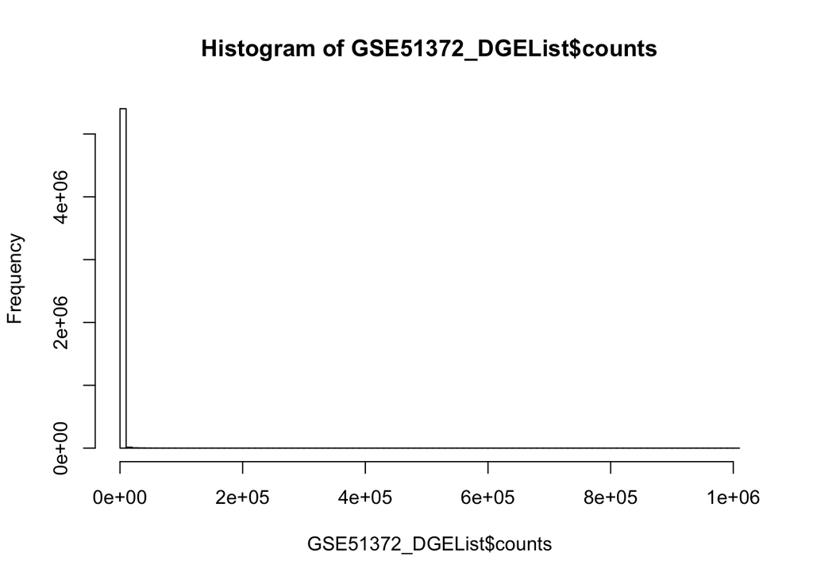

```r
hist(GSE51372_DGEList$counts, breaks = 100)
```

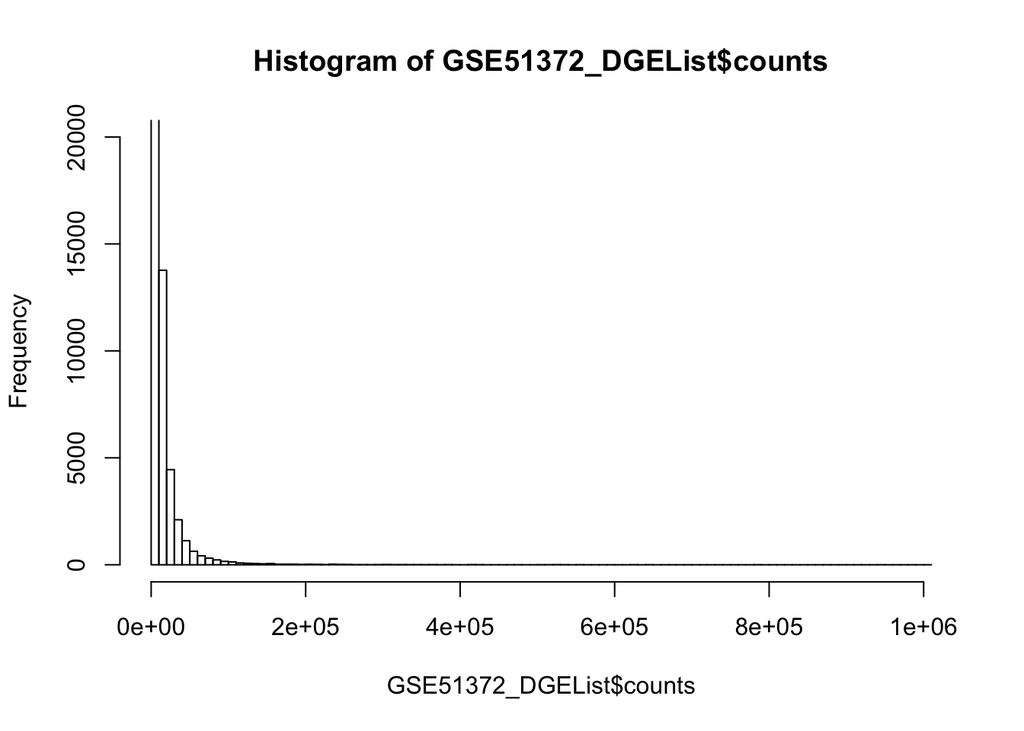

```r
hist(GSE51372_DGEList$counts, breaks = 100, ylim = c(0, 20000))
```

It’s clear that there is an overabundance of low counts, particularly zero. We will explore this more later.

First a common step is to restrict analysis to cells with sufficiently high counts to prevent analysis on empty wells and genes that are observed in a sufficient number of cells. On the former, most analysis uses an arbitrary number for the restriction. Instead I will use a normal-type cutoff, removing those cells with gene sums less than two standard deviations away from the mean gene sum over all cells.

```r
which(colSums(GSE51372_DGEList$counts) < mean(colSums(GSE51372_DGEList$counts)) - 2*sd(colSums(GSE51372_DGEList$counts)))
```

```
## named integer(0)
```

Now to look at the gene cut-off.

```r
lapply(1:6, function(x) length(which(rowSums(GSE51372_DGEList$counts > 0) > x)))
```

```
## [[1]]
## [1] 18044
##
## [[2]]
## [1] 17251
##
## [[3]]
## [1] 16655
##
## [[4]]
## [1] 16261
##
## [[5]]
## [1] 15889
##
## [[6]]
## [1] 15600
```

```r
GSE51372_DGEList$genes = GSE51372_DGEList$genes[which(rowSums(GSE51372_DGEList$counts > 0) > 4),]
GSE51372_DGEList$counts = GSE51372_DGEList$counts[which(rowSums(GSE51372_DGEList$counts > 0) > 4),]
dim(GSE51372_DGEList$genes)
```

```
## [1] 16261     6
```

```r
dim(GSE51372_DGEList$counts)
```

```
## [1] 16261   187
```

We need to separate by cell type, contained in the 7th row of GSE51372_design_matrix. The different cell types and their corresponding labels are as follows.

| Cell type | Label |
| --- | --- |
| single tumor cell circulating in mouse blood | 1 |
| single mouse embryonic fibroblast cell | 2 |
| single cell circulating in mouse blood enriched for tumor cells | 3 |
| single cell from NB508 mouse pancreatic cancer cell line | 4 |
| single cancer cell from the primary pancreatic tumor in a mouse | 5 |
| mouse pancreatic tumor | 6 |
| single mouse white blood cell | 7 |

```r
GSE51372_DGEList$samples$group = c(rep(1, times = length(which(GSE51372_design_matrix[7,2:188] == "single tumor cell circulating in mouse blood"))), rep(2, times = length(which(GSE51372_design_matrix[7,2:188] == "single mouse embryonic fibroblast cell"))), rep(3, times = length(which(GSE51372_design_matrix[7,2:188] == "single cell circulating in mouse blood enriched for tumor cells"))), rep(4, times = length(which(GSE51372_design_matrix[7,2:188] == "single cell from NB508 mouse pancreatic cancer cell line"))), rep(5, times = length(which(GSE51372_design_matrix[7,2:188] == "single cancer cell from the primary pancreatic tumor in a mouse"))), rep(6, times = length(which(GSE51372_design_matrix[7,2:188] == "mouse pancreatic tumor"))), rep(7, times = length(which(GSE51372_design_matrix[7,2:188] == "single mouse white blood cell"))))
GSE51372_DGEList$samples$group
```

```
##   [1] 1 1 1 1 1 1 1 1 1 1 1 1 1 1 1 1 1 1 2 2 2 2 2 2 2 2 2 2 2 2 3 3 3 3 3
##  [36] 3 3 3 3 3 3 3 3 3 3 3 3 3 3 3 3 3 3 3 3 3 3 3 3 3 3 3 3 3 3 3 3 3 3 3
##  [71] 3 3 3 3 3 3 3 3 3 3 3 3 3 3 3 3 3 3 3 3 3 3 3 3 3 3 3 3 3 3 3 3 3 3 3
## [106] 4 4 4 4 4 4 4 4 4 4 4 4 4 4 4 4 5 5 5 5 5 5 5 5 5 5 5 5 5 5 5 5 5 5 5
## [141] 5 6 6 6 6 6 6 6 6 6 6 6 6 6 6 6 6 6 6 6 6 6 6 6 6 6 6 6 6 6 6 6 6 6 6
## [176] 7 7 7 7 7 7 7 7 7 7 7 7
```

# Examining the data

Let’s look at a simple principal component analysis on the data.

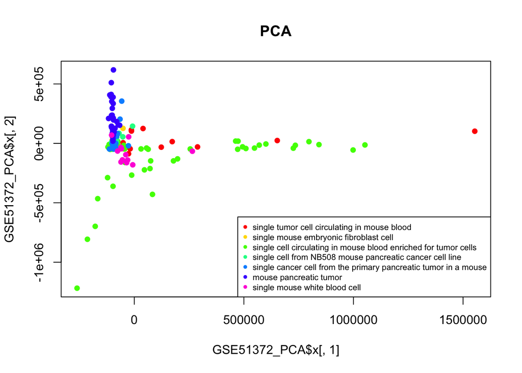

```r
GSE51372_PCA = prcomp(t(GSE51372_DGEList$counts))
plot(GSE51372_PCA$x[,1], GSE51372_PCA$x[,2], col=rainbow(7)[GSE51372_DGEList$samples$group], pch=16, main = "PCA")
legend("bottomright", legend = c("single tumor cell circulating in mouse blood", "single mouse embryonic fibroblast cell", "single cell circulating in mouse blood enriched for tumor cells", "single cell from NB508 mouse pancreatic cancer cell line", "single cancer cell from the primary pancreatic tumor in a mouse", "mouse pancreatic tumor", "single mouse white blood cell"), col = rainbow(7)[1:7], pch = 16, cex = 0.67)
```

It appears that most of the variation in the data is from the circulating tumor cells and cells circulating in tumor enriched blood. A confounding factor may be sequencing depth, so let’s look at that.

```r
x = GSE51372_DGEList$samples$lib.size[c(which(GSE51372_DGEList$samples$group == 1), which(GSE51372_DGEList$samples$group == 3))]
y = GSE51372_DGEList$samples$lib.size[c(which(GSE51372_DGEList$samples$group == 2), which(GSE51372_DGEList$samples$group == 4), which(GSE51372_DGEList$samples$group == 5), which(GSE51372_DGEList$samples$group == 6), which(GSE51372_DGEList$samples$group == 7))]
t.test(x, y)
```

```
##
##  Welch Two Sample t-test
##
## data:  x and y
## t = 1.7323, df = 179.13, p-value = 0.08494
## alternative hypothesis: true difference in means is not equal to 0
## 95 percent confidence interval:
##  -129563.7 1992436.6
## sample estimates:
## mean of x mean of y
##   7087381   6155945
```

Not a significant difference but certainly a factor. Obviously there are other factors at play here and more complicated clustering will take more time than I am willing to discuss here.

# Naive differential expression with edgeR

Now let’s get to the meat of this analysis: differential expression analysis with edgeR, but without taking into account for problems specific to single cell sequencing. Let’s restrict our analysis to a simple two factor analysis by looking at only two cell types: circulating tumor cells and primary pancreatic tumor cells.

```r
GSE51372_CTC_vs_PTC_DGEList = GSE51372_DGEList
GSE51372_CTC_vs_PTC_DGEList$samples = GSE51372_CTC_vs_PTC_DGEList$samples[c(which(GSE51372_CTC_vs_PTC_DGEList$samples$group == 1), which(GSE51372_CTC_vs_PTC_DGEList$samples$group == 5)),]
GSE51372_CTC_vs_PTC_DGEList$counts = GSE51372_CTC_vs_PTC_DGEList$counts[ , c(which(GSE51372_CTC_vs_PTC_DGEList$samples$group == 1), which(GSE51372_CTC_vs_PTC_DGEList$samples$group == 5))]
GSE51372_CTC_vs_PTC_DGEList = calcNormFactors(GSE51372_CTC_vs_PTC_DGEList)
GSE51372_CTC_vs_PTC_DGEList.design = model.matrix(~as.factor(GSE51372_CTC_vs_PTC_DGEList$samples$group))
```

Let’s look at the edgeR dispersion factor for these two cell types.

```r
GSE51372_CTC_vs_PTC_DGEList = estimateDisp(GSE51372_CTC_vs_PTC_DGEList, GSE51372_CTC_vs_PTC_DGEList.design)
GSE51372_CTC_vs_PTC_DGEList$common.dispersion
```

```
## [1] 8.04776
```

This is considerably higher than the examples in the edgeR example cases (see [the vignette](https://bioconductor.org/packages/release/bioc/vignettes/edgeR/inst/doc/edgeRUsersGuide.pdf)).

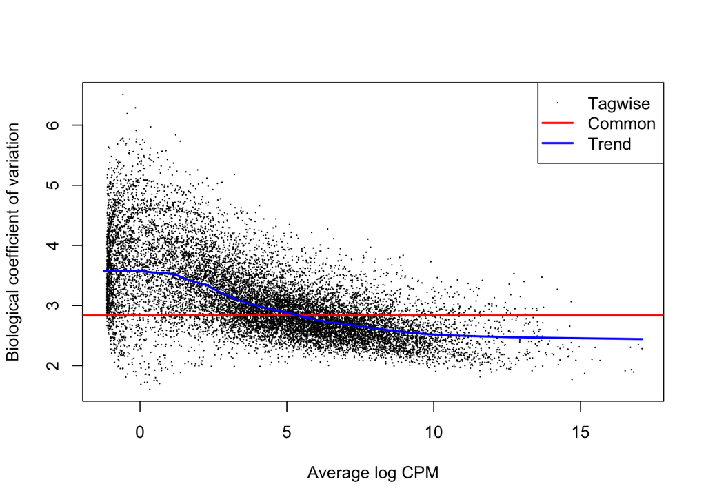

```r
plotBCV(GSE51372_CTC_vs_PTC_DGEList)
```

## Differential Expression

Now to the differential expression analysis.

```r
GSE51372_CTC_vs_PTC_glm = glmFit(GSE51372_CTC_vs_PTC_DGEList, GSE51372_CTC_vs_PTC_DGEList.design)
GSE51372_CTC_vs_PTC_glm_lrt = glmLRT(GSE51372_CTC_vs_PTC_glm)
topTags(GSE51372_CTC_vs_PTC_glm_lrt)
```

```
## Coefficient:  as.factor(GSE51372_CTC_vs_PTC_DGEList$samples$group)5
##                 ID_REF Entrez GeneID   uniGene symbol
## 15278  eg:57349:chr5:p         57349 Mm.293614   Ppbp
## 15182  eg:56760:chr6:p         56760  Mm.30700 Clec1b
## 2784  eg:13024:chr13:m         13024 Mm.482089 Ctla2a
## 21802  eg:98932:chr2:p         98932 Mm.271770   Myl9
## 15173  eg:56744:chr5:p         56744 Mm.332490    Pf4
## 5098  eg:18022:chr15:m         18022 Mm.457989   Nfe2
## 2785  eg:13025:chr13:m         13025  Mm.30144 Ctla2b
## 19987 eg:74145:chr13:m         74145 Mm.235105  F13a1
## 2875  eg:13179:chr10:p         13179  Mm.56769    Dcn
## 1929  eg:11684:chr11:m         11684  Mm.12286 Alox12
##                                                    name mm9 knownGene ID
## 15278                        Pro-platelet basic protein
## 15182           C-type lectin domain family 1, member b
```

[output cut: 19 more lines]

Let’s take a look at the top two genes identified, Ppbp and Clec1b.

```r
GSE51372_CTC_vs_PTC_DGEList$counts[which(GSE51372_CTC_vs_PTC_DGEList$genes$symbol == "Ppbp"),]
```

```
##  GMP1-1-030413  GMP1-2-030413  GMP1-3-030413  GMP1-4-030413  GMP1-5-030413
##           2132           2003           4660           3525           4330
##  GMP1-6-030413  GMP1-7-030413  GMP2-1-040513 GMP2-10-040513 GMP2-11-040513
##           2384            422          41514          10738          36346
##  GMP2-2-040513  GMP2-3-040513  GMP2-4-040513  GMP2-5-040513  GMP2-6-040513
##          18522         873925         719638          91798          42906
##  GMP2-7-040513  GMP2-8-040513  GMP2-9-040513          MEF-1         MEF-10
##           3727         161859           9362              0              0
##         MEF-11         MEF-12          MEF-2          MEF-3          MEF-4
##              0              0              0              3              0
##          MEF-5          MEF-6          MEF-7          MEF-8          MEF-9
##              0              0              0              3              0
##          MP2-1         MP2-11         MP2-17         MP2-18          MP2-2
##              0              0              1              0              3
##         MP2-20         MP2-21         MP2-24
##              2              3              1
```

```r
GSE51372_CTC_vs_PTC_DGEList$counts[which(GSE51372_CTC_vs_PTC_DGEList$genes$symbol == "Clec1b"),]
```

```
##  GMP1-1-030413  GMP1-2-030413  GMP1-3-030413  GMP1-4-030413  GMP1-5-030413
##           2228            181           6562            874          11765
##  GMP1-6-030413  GMP1-7-030413  GMP2-1-040513 GMP2-10-040513 GMP2-11-040513
##            578             14            929             17          17991
##  GMP2-2-040513  GMP2-3-040513  GMP2-4-040513  GMP2-5-040513  GMP2-6-040513
##           9419         242879          32703          17590            527
##  GMP2-7-040513  GMP2-8-040513  GMP2-9-040513          MEF-1         MEF-10
##             73          28176            958              0              0
##         MEF-11         MEF-12          MEF-2          MEF-3          MEF-4
##              0              0              0              0              0
##          MEF-5          MEF-6          MEF-7          MEF-8          MEF-9
##              0              0              0              0              0
##          MP2-1         MP2-11         MP2-17         MP2-18          MP2-2
##              3              1              3              2              4
##         MP2-20         MP2-21         MP2-24
##              5              3              2
```

These are genes that are highly expressed in one cell and not the other.

```r
summary(GSE51372_CTC_vs_PTC_glm_lrt_de <- decideTestsDGE(GSE51372_CTC_vs_PTC_glm_lrt, adjust.method = "BH"))
```

```
##    [,1]
## -1 1513
## 0  9979
## 1  4769
```

```r
sum(abs(GSE51372_CTC_vs_PTC_glm_lrt_de))/length(GSE51372_CTC_vs_PTC_glm_lrt_de)
```

```
## [1] 0.3863231
```

Nearly 40% of the genes considered are called differentially expressed, even with Benjamini-Hochberg correction. The called differentially expressed genes are available in Supplementary Table S1. The second column contains the genes upregulated in CTCs versus the primary tumor cells and the third column contains genes upregulated in the primary tumor cells versus CTCs. Let’s compare our results versus theirs.

```r
GSE51372_diffentially_expressed = read.delim(file = "GSE51372_diffentially_expressed.txt", stringsAsFactors=FALSE)
length(intersect(GSE51372_diffentially_expressed[,2], GSE51372_CTC_vs_PTC_DGEList$genes$symbol[which(GSE51372_CTC_vs_PTC_glm_lrt_de > 0)]))/(881-3)
```

```
## [1] 0.4669704
```

```r
length(intersect(GSE51372_diffentially_expressed[,3], GSE51372_CTC_vs_PTC_DGEList$genes$symbol[which(GSE51372_CTC_vs_PTC_glm_lrt_de < 0)]))/(777-3)
```

```
## [1] 0.07881137
```

```r
GSE51372_CTC_vs_PTC_glm_lrt_CTCenriched = GSE51372_CTC_vs_PTC_glm_lrt
GSE51372_CTC_vs_PTC_glm_lrt_CTCenriched$table = GSE51372_CTC_vs_PTC_glm_lrt_CTCenriched$table[which(GSE51372_CTC_vs_PTC_glm_lrt_CTCenriched$table$logFC > 0),]
GSE51372_CTC_vs_PTC_glm_lrt_CTCenriched_top878 = topTags(GSE51372_CTC_vs_PTC_glm_lrt_CTCenriched, n = 878)
length(intersect(GSE51372_CTC_vs_PTC_glm_lrt_CTCenriched_top878$table$symbol, GSE51372_diffentially_expressed[,2]))
```

```
## [1] 60
```

Hmmm. Disappointing.